### Part II

#### Solution

Tuesday, May 20, 2014

**5.** Consider the first five rows of the data set `problem5.txt`:

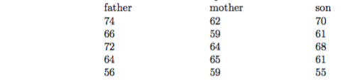

There are twenty $(20)$ data lines total. The values represent the adult heights in inches of the father, mother, and son of twenty randomly-selected families. Justify your answers (if you use a computer package to do calculations, explain what you did) for full credit.

Read in data. Option 1: copy and paste

```r
raw.text <- "
dad  mom  son
74   62   69
66   59   60
72   64   67
64   65   60
56   59   54
66   64   61
67   64   63
74   59   65
72   62   67
73   63   68
75   65   67
63   64   62
69   57   61
74   63   67
68   61   61
67   70   66
63   59   58
74   63   67
63   65   62
67   68   67
"

height.df <- read.table(header=TRUE, text=raw.text)
```

Read in data. Option 2: from url

```r
# Data is fixed width
height <- read.fwf(file="http://algebra.sci.csueastbay.edu/~esuess/msexam/pastmsexam/2014/Spring2014/problem5.txt",
                   widths=c(5, 5, 2), # specify the spaces of each column
                   header=FALSE, #spacing is mismatched, so ignore header
                   skip=1) # skip 1st line, which is the header
```

**a)** [7 points] Consider the father and mother.

**a.i)** Is this enough evidence to show that the heights are correlated? (Use $\alpha = 0.05$).  
**Solution**  
$H_0: \rho_{dad,mom}=0$  
$H_a: \rho_{dad,mom} \neq 0$

```r
cor.test(x=height.df$dad, y=height.df$mom)
```

```
##
##  Pearson's product-moment correlation
##
## data:  height.df$dad and height.df$mom
## t = 0.23797, df = 18, p-value = 0.8146
## alternative hypothesis: true correlation is not equal to 0
## 95 percent confidence interval:
##  -0.3963408  0.4864672
## sample estimates:
##        cor
## 0.05600209
```

$\hat{\rho}_{dad,mom} = 0.056$.  
With a *p*-value of 0.8146, there is not enough evidence to show that the heights of the parents are correlated.

**a.ii)** Give a 95% confidence interval for the difference of the heights between the fathers and mothers.  
**Solution**

```r
t.test(x=height.df$dad, y=height.df$mom, paired=TRUE) # 95% CI is default
```

```
##
##  Paired t-test
##
## data:  height.df$dad and height.df$mom
## t = 4.2275, df = 19, p-value = 0.0004558
## alternative hypothesis: true difference in means is not equal to 0
## 95 percent confidence interval:
##  2.802191 8.297809
## sample estimates:
## mean of the differences
##                    5.55
```

I am 95% confident that the mean difference between the heights of the fathers and mothers is between 2.8 and 8.3 inches.

```r
cor.test(x=height.df$dad, y=height.df$son)
```

```
##
##  Pearson's product-moment correlation
##
## data:  height.df$dad and height.df$son
## t = 7.2427, df = 18, p-value = 9.802e-07
## alternative hypothesis: true correlation is not equal to 0
## 95 percent confidence interval:
##  0.6799730 0.9446721
## sample estimates:
##       cor
## 0.8628579
```

$\hat{\rho}_{dad,son} = 0.8629$.  
With a *p*-value $< 0.001$, there is enough evidence to show that the heights of the father and son are correlated.

**b.ii)** Give a 95% confidence interval for the difference of the heights between the fathers and sons.  
**Solution**

```r
t.test(x=height.df$dad, y=height.df$son, paired=TRUE)
```

```
##
##  Paired t-test
##
## data:  height.df$dad and height.df$son
## t = 8.1289, df = 19, p-value = 1.321e-07
## alternative hypothesis: true difference in means is not equal to 0
## 95 percent confidence interval:
##  3.526973 5.973027
## sample estimates:
## mean of the differences
##                    4.75
```

I am 95% confident that the mean difference between the heights of the fathers and sons is between 3.5 and 6.0 inches.

**c)** [7 points] Consider the mother and son.  
**c.i)** Is this enough evidence to show that the heights are correlated? (Use $\alpha = 0.05$).  
**Solution**  
$H_0: \rho_{mom,son}=0$  
$H_a: \rho_{mom,son} \neq 0$

```r
cor.test(x=height.df$mom, y=height.df$son)
```

```
##
##  Pearson's product-moment correlation
##
## data:  height.df$mom and height.df$son
## t = 2.1714, df = 18, p-value = 0.04351
## alternative hypothesis: true correlation is not equal to 0
## 95 percent confidence interval:
##  0.01639069 0.74743346
## sample estimates:
##       cor
## 0.4556069
```

**c.ii)** Give a 95% confidence interval for the difference of the heights between the mothers and sons.  
**Solution**

```r
t.test(x=height.df$mom, y=height.df$son, paired=TRUE)
```

```
##
##  Paired t-test
##
## data:  height.df$mom and height.df$son
## t = -0.94006, df = 19, p-value = 0.359
## alternative hypothesis: true difference in means is not equal to 0
## 95 percent confidence interval:
##  -2.5811752  0.9811752
## sample estimates:
## mean of the differences
##                    -0.8
```

I am 95% confident that the mean difference between the heights of the mothers and sons is between -2.6 and 1.0 inches.

**d)** Looking at the results from parts (a), (b), and (c), do your inferences make sense in the context of the data set? Why or why not?  
**Solution** “While it makes sense that the parents’ heights are correlated with the sons’ heights, it seems weird that the fathers are significantly taller than their sons, but the mothers are about the same height.”